# DV Assignment 2: Same test results, different advice?

Group 8: Alice Školoudíková, Robin Lux

2026-10-10

## Research question

**Do schools with similar test results give similar secondary-school advice, regardless of how disadvantaged their pupils are?** (RQ3, inference level)

Our audience is the teachers at the secondary schools who give advice to pupils for the tracks. Because switching the track later is quite hard, it matters that the advice is fair and based on the pupils’ results, and not on the school they come from. We want to show the teachers that it happens systematically, that children with the same results can receive different advice depending on the disadvantage of their primary school.

Teachers cannot be expected to know what “controlling for test results” means, so we are trying to show that in the figure. Disadvantaged schools have lower results on average, so we compare schools at the same test results and count in number of pupils, because teachers might be more likely to understand this metric.

## Data and exploratory process

We kept regular primary schools, joined advice, reference levels and school weighting (*schoolweging*), and dropped schools with more than one location (no single school weighting), leaving 5,526 of 6,122 schools.

- **Test results:** one number per school, the share of all maths, reading and writing results at target level (1S for maths, 2F for reading and writing), because our question is about results as a whole.
- **Advice:** we tried the share of pupils with HAVO or higher advice (HAVO+) and a mean advice from 1 (PRO) to 6 (VWO). Both showed the same pattern, weaker for the mean, which also treats an ordinal scale as if the tracks were equally far apart. So we kept HAVO+.
- **Hidden counts:** DUO shows counts of 1 to 4 pupils as “<5”. We used 2.5 and checked 1 and 4 later.
- **Disadvantage:** three equal groups by school weighting.

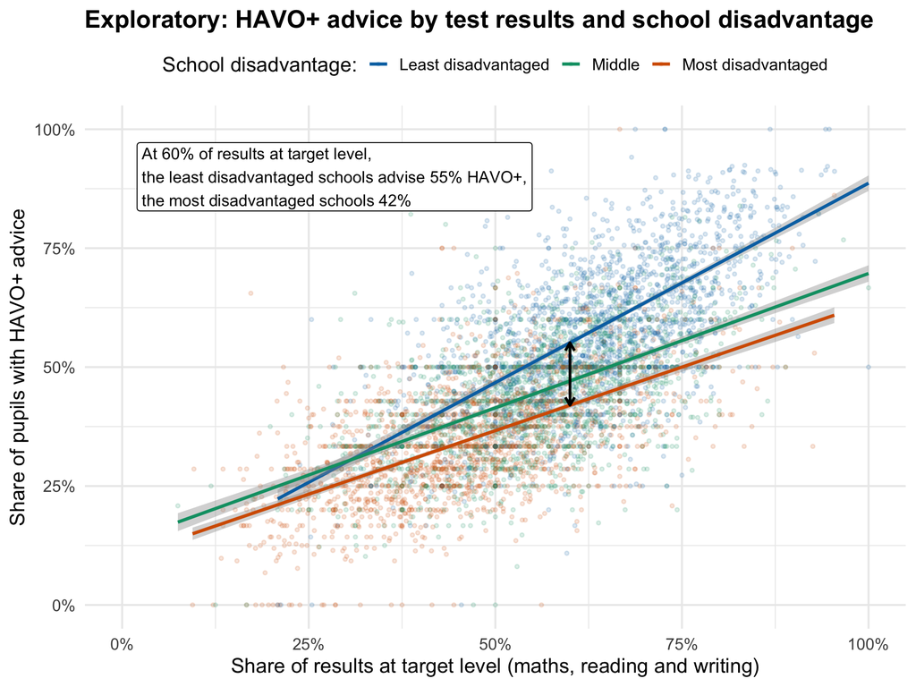

```r
# Exploratory plot: HAVO+ advice vs test results
explore_fits <- group_fit(schools, "pct_havo_plus", at = 0.6)
make_scatter(
  schools, "pct_havo_plus",
  title = "Exploratory: HAVO+ advice by test results and school disadvantage",
  y_label = "Share of pupils with HAVO+ advice", show_legend = TRUE
) |>
  add_gap_label(explore_fits, at = 0.6,
                label_x = 0.02, label_y = 0.9, hjust = 0)
```

What the plot showed, and what we changed:

1. The lines have different slopes. The middle group sits in between and makes it more cluttered, so we compare only the most and the least disadvantaged third.
2. Because reading the gap between the lines is quite hard, in the final figure we pick one point (national average), and shows what the lines predict using example of 100 pupils.
3. The lines move apart as results increase, so one panel shows the gap over the whole range. Because small schools are noisy, we weight them by groep 8 pupils.

## Final visualization

**This is our final, explanatory visualization.**

```r
## ---- Shared style ----------------------------------------------------------

## One font for the whole figure (downloaded from Google Fonts)
font_add_google("Inter", "inter")
showtext_auto()

## Colours: grey for context, one colour per highlighted group
ink <- "#1F1F1F"
muted <- "#4F4F4F"
dot_grey <- "#B8B8B8"
blue <- "#0072B2"
orange <- "#D55E00"
middle_grey <- "#8A8A8A"
gap_fill <- "#E9E9E9"

## One colour per disadvantage group (used in panels 1 and 3)
line_colours <- c(
  "Least disadvantaged" = blue,
  "Middle" = middle_grey,
  "Most disadvantaged" = orange
)

## Shared theme: white background, light horizontal gridlines only
theme_story <- function() {
  theme_minimal(base_size = 18, base_family = "inter") +
    theme(
      plot.title = element_text(
        face = "bold", size = 22, colour = ink, lineheight = 1.15,
        margin = margin(b = 10)
      ),
      plot.subtitle = element_text(
        size = 17, colour = muted, lineheight = 1.2, margin = margin(b = 24)
      ),
      axis.title = element_text(size = 17, colour = ink),
      axis.title.x = element_text(margin = margin(t = 16)),
      axis.title.y = element_text(margin = margin(r = 16)),
      axis.text = element_text(size = 15, colour = muted),
      panel.grid.major.x = element_blank(),
      panel.grid.minor = element_blank(),
      panel.grid.major.y = element_line(colour = "#ECECEC", linewidth = 0.4),
      plot.margin = margin(20, 30, 50, 20)
    )
}

## Axes shared by panels 1 and 3
pct_axis <- function(name) {
  scale_x_continuous(
    name = name, labels = scales::percent, limits = c(0, 1),
    breaks = seq(0, 1, 0.2), expand = expansion(mult = 0.02),
    # keep arrows that end outside the plot
    oob = scales::oob_keep
  )
}
x_title <- "Test results (share of results at target level)"
y_title <- "Share of pupils receiving HAVO+ advice"

## ---- Numbers used in all three panels --------------------------------------

# National share of maths, reading and writing results at target level
national_target <- levels_clean |>
  summarise(
    share = sum(
      pct_maths_1s * n_maths + pct_reading_2f * n_reading +
        pct_writing_2f * n_writing,
      na.rm = TRUE
    ) / sum(n_maths + n_reading + n_writing)
  ) |>
  pull(share)
national_label <- scales::percent(national_target, accuracy = 1)

# HAVO+ share the regression line of the advantaged and the disadvantaged
fits_avg <- group_fit(schools, "pct_havo_plus", at = national_target)

## ---- Panel 1: all schools ---------------------------------------------------

# Linear regression line over all schools, weighted by the number of groep 8
all_fit <- lm(pct_havo_plus ~ pct_target, data = schools, weights = n_groep8)
all_line <- tibble(
  pct_target = quantile(schools$pct_target, c(0.01, 0.99))
) |>
  mutate(pct_havo_plus = predict(all_fit, newdata = pick(everything())))

# Correlation between test results and HAVO+ advice
all_r <- cov.wt(
  select(schools, pct_target, pct_havo_plus),
  wt = schools$n_groep8, cor = TRUE
)$cor[1, 2]
line_label <- slice_max(all_line, pct_target, n = 1) |>
  mutate(label = paste("r =", format(round(all_r, 2), nsmall = 2)))

## Average share of results at target level
group_avg <- schools |>
  filter(disadvantage != "Middle") |>
  group_by(disadvantage) |>
  summarise(
    x = sum(pct_target * (n_maths + n_reading + n_writing)) /
      sum(n_maths + n_reading + n_writing)
  ) |>
  mutate(
    label = paste(
      scales::percent(x, accuracy = 1),
      if_else(
        disadvantage == "Least disadvantaged", "advantaged", "disadvantaged"
      ),
      "\naverage"
    ),
    # label left of the lower average, right of the higher one
    hjust = if_else(disadvantage == "Least disadvantaged", 0, 1),
    nudge = if_else(disadvantage == "Least disadvantaged", 0.015, -0.015)
  )

# Where the arrows should end
arrow_end_x <- 1.53
arrow_end_y <- c("Least disadvantaged" = 0.69, "Most disadvantaged" = 0.24)

# Predicted HAVO+ share of the advantaged and the disadvantaged schools
avg_points <- tibble(
  disadvantage = c("Least disadvantaged", "Most disadvantaged"),
  x = national_target,
  y = unname(fits_avg)
)

# Dot colour per school
dot_colours <- c(
  "Least disadvantaged" = blue,
  "Middle" = dot_grey,
  "Most disadvantaged" = orange
)

p1 <- ggplot(
  # middle group first, so the blue and orange dots are on top
  arrange(schools, disadvantage != "Middle"),
  aes(x = pct_target, y = pct_havo_plus)
) +
  # one light dot per school, coloured by disadvantage group
  geom_point(aes(colour = disadvantage), size = 1.8, alpha = 0.12) +
  scale_colour_manual(values = dot_colours, guide = "none") +
  # national average on top of the dots
  geom_vline(
    xintercept = national_target, linetype = "dashed", colour = ink,
    linewidth = 0.9
  ) +
  # average test results of the advantaged and the disadvantaged schools
  geom_vline(
    data = group_avg, aes(xintercept = x, colour = disadvantage),
    linetype = "dashed", linewidth = 0.9
  ) +
  # their labels on a white box
  geom_label(
    data = group_avg,
    aes(x = x + nudge, y = 0.06, label = label, colour = disadvantage,
        hjust = hjust),
    size = 5.4, fontface = "bold", family = "inter", fill = "white",
    border.colour = "white", lineheight = 0.9
  ) +
  # regression line over all schools
  geom_line(
    data = all_line, aes(x = pct_target, y = pct_havo_plus),
    colour = ink, linewidth = 1.1
  ) +
  # arrows from the national average to the pupil grids in panel 2
  annotate(
    "curve",
    x = national_target + 0.01, y = fits_avg[["Least disadvantaged"]],
    xend = arrow_end_x, yend = arrow_end_y[["Least disadvantaged"]],
    curvature = -0.15, colour = ink, linewidth = 0.8,
    arrow = arrow(length = unit(0.15, "inches"), type = "closed")
  ) +
  annotate(
    "curve",
    x = national_target + 0.01, y = fits_avg[["Most disadvantaged"]],
    xend = arrow_end_x, yend = arrow_end_y[["Most disadvantaged"]],
    curvature = 0.25, colour = ink, linewidth = 0.8,
    arrow = arrow(length = unit(0.15, "inches"), type = "closed")
  ) +
  # points at the national average, where the arrows start
  geom_point(
    data = avg_points, aes(x = x, y = y, fill = disadvantage),
    shape = 21, size = 5, colour = "white", stroke = 1.5
  ) +
  # correlation at the end of the regression line
  geom_text(
    data = line_label,
    aes(x = pct_target + 0.015, y = pct_havo_plus, label = label),
    colour = ink, hjust = 0, size = 6, fontface = "bold", family = "inter"
  ) +
  scale_fill_manual(values = line_colours, guide = "none") +
  coord_cartesian(clip = "off") +
  # label of the national average on a white box
  annotate(
    "label",
    x = national_target, y = 1.08,
    label = paste(national_label, "national average"),
    hjust = 0.5, size = 5.4, fontface = "bold", colour = ink,
    family = "inter", fill = "white", label.size = 0
  ) +
  pct_axis(x_title) +
  scale_y_continuous(
    name = y_title, labels = scales::percent, limits = c(0, 1),
    # keep the national-average label above the plot
    oob = scales::oob_keep
  ) +
  labs(
    title = "1  Better test results, more HAVO+ advice",
    subtitle = "But schools with the same results still differ a lot"
  ) +
  theme_story()
```

```r
## ---- Panel 2: 100 pupils at an average school ------------------------------

## One pupil grid each for the advantaged and the disadvantaged schools
grid_groups <- tibble(
  group = factor(
    c("More advantaged\nschools", "More disadvantaged\nschools"),
    levels = c("More advantaged\nschools", "More disadvantaged\nschools")
  ),
  colour = c(blue, orange),
  n_havo = round(100 * unname(fits_avg)),
  label = "pupils receive\nHAVO+ advice"
)

# Pupil icon in a 1 x 1 cell
circle <- seq(0, 2 * pi, length.out = 30)
shoulders <- seq(0, pi, length.out = 20)
pupil_shape <- bind_rows(
  tibble(x = 0.15 * cos(circle), y = 0.24 + 0.15 * sin(circle), part = "h"),
  tibble(
    x = c(0.3 * cos(shoulders), -0.3, 0.3),
    y = c(-0.12 + 0.28 * sin(shoulders), -0.42, -0.42),
    part = "b"
  )
)

# 100 pupils on a 10 x 10 grid
pupils <- grid_groups |>
  cross_join(tibble(pupil = 1:100)) |>
  mutate(
    col = (pupil - 1) %% 10,
    row = (pupil - 1) %/% 10,
    fill = if_else(pupil <= n_havo, colour, "#E4E4E4")
  ) |>
  cross_join(pupil_shape) |>
  mutate(x = col + x, y = row + y, id = paste(group, pupil, part))

p2 <- ggplot(pupils, aes(x = x, y = y)) +
  geom_polygon(aes(group = id, fill = fill)) +
  # big number and "pupils receive HAVO+ advice" to the right of each grid
  geom_text(
    data = grid_groups, aes(x = 10.5, y = 5.6, label = n_havo, colour = colour),
    hjust = 0, size = 15, fontface = "bold", family = "inter"
  ) +
  geom_text(
    data = grid_groups, aes(x = 10.6, y = 2.4, label = label),
    hjust = 0, size = 6.5, colour = muted, family = "inter", lineheight = 0.9
  ) +
  # grids under each other
  facet_wrap(~group, ncol = 1) +
  scale_fill_identity() +
  scale_colour_identity() +
  coord_fixed(xlim = c(-0.6, 16), ylim = c(-0.7, 9.7), clip = "off") +
  labs(
    title = "2  Same test results, different advice",
    subtitle = paste0(
      "Expected out of 100 pupils at national-average\nresults (",
      national_label, ")"
    )
  ) +
  theme_story() +
  theme(
    # hide axes, gridlines and facet labels around the pupil grids
    axis.text = element_blank(), axis.title = element_blank(),
    axis.title.x = element_blank(), axis.title.y = element_blank(),
    panel.grid.major.y = element_blank(), strip.text = element_blank(),
    panel.spacing = unit(5, "lines"),
    # extra space on the left to centre the grids in the right column
    plot.margin = margin(20, 30, 50, 135)
  )

## ---- Panel 3: the gap grows with test results ------------------------------

## Regression line for the advantaged and the disadvantaged
group_lines <- schools |>
  filter(disadvantage != "Middle") |>
  group_by(disadvantage) |>
  group_modify(function(d, key) {
    fit <- lm(pct_havo_plus ~ pct_target, data = d, weights = d$n_groep8)
    grid <- tibble(pct_target = seq(
      quantile(d$pct_target, 0.01), quantile(d$pct_target, 0.99),
      length.out = 50
    ))
    pred <- predict(fit, grid, interval = "confidence")
    bind_cols(grid, as_tibble(pred))
  }) |>
  ungroup()

## Shaded gap between the least and the most disadvantaged schools
gap_range <- group_lines |>
  group_by(disadvantage) |>
  summarise(lo = min(pct_target), hi = max(pct_target))
gap_x <- seq(max(gap_range$lo), min(gap_range$hi), length.out = 50)
gap_band <- tibble(pct_target = gap_x) |>
  mutate(
    top = map_dbl(pct_target, function(x) {
      group_fit(schools, "pct_havo_plus", at = x)[["Least disadvantaged"]]
    }),
    bottom = map_dbl(pct_target, function(x) {
      group_fit(schools, "pct_havo_plus", at = x)[["Most disadvantaged"]]
    })
  )

## Gap bars and labels (relative gap) at 40%, 60% and 80% of results
gap_points <- tibble(pct_target = c(0.4, 0.6, 0.8)) |>
  mutate(
    top = map_dbl(pct_target, function(x) {
      group_fit(schools, "pct_havo_plus", at = x)[["Least disadvantaged"]]
    }),
    bottom = map_dbl(pct_target, function(x) {
      group_fit(schools, "pct_havo_plus", at = x)[["Most disadvantaged"]]
    }),
    # relative gap: how much more HAVO+ advice the advantaged schools give
    label = paste0(round(100 * (top - bottom) / bottom), "% more"),
    # label in the plot: the last one also says compared to whom
    plot_label = if_else(
      pct_target == max(pct_target),
      paste(label, "than\ndisadvantaged schools"),
      label
    )
  )

## Line labels at the right end of each line
end_labels <- group_lines |>
  group_by(disadvantage) |>
  slice_max(pct_target, n = 1) |>
  ungroup() |>
  mutate(label = c("Advantaged schools", "Disadvantaged schools"))

## Smoothed distribution of the schools' test results per group
density_height <- 0.14
school_density <- schools |>
  filter(disadvantage != "Middle") |>
  group_by(disadvantage) |>
  group_modify(function(d, key) {
    dens <- density(d$pct_target, from = 0, to = 1, n = 200)
    tibble(pct_target = dens$x, density = dens$y)
  }) |>
  ungroup() |>
  mutate(density_y = density / max(density) * density_height)

# Weighted regression with an interaction term
outer_schools <- schools |>
  filter(disadvantage != "Middle") |>
  droplevels() |>
  # centring: 0 = national average, in steps of 10 points; HAVO+ in pp
  mutate(
    results_10 = (pct_target - national_target) * 10,
    havo_pp = pct_havo_plus * 100
  )
interaction_fit <- lm(
  havo_pp ~ results_10 * disadvantage,
  data = outer_schools, weights = n_groep8
)

# Gap at the national average and its growth per 10 points
gap_terms <- c(
  "disadvantageMost disadvantaged",
  "results_10:disadvantageMost disadvantaged"
)
gap_coefs <- summary(interaction_fit)$coefficients[gap_terms, ]
# 95% confidence intervals
gap_ci <- confint(interaction_fit)[gap_terms, ]

p3 <- ggplot(group_lines, aes(x = pct_target)) +
  # distribution of the schools along the test results
  geom_ribbon(
    data = school_density,
    aes(ymin = 0, ymax = density_y, group = disadvantage),
    fill = dot_grey, alpha = 0.25
  ) +
  geom_line(
    data = school_density, aes(y = density_y, colour = disadvantage),
    linewidth = 0.8
  ) +
  geom_ribbon(
    data = gap_band, aes(ymin = bottom, ymax = top), fill = gap_fill
  ) +
  geom_ribbon(
    aes(ymin = lwr, ymax = upr, fill = disadvantage), alpha = 0.25
  ) +
  geom_line(aes(y = fit, colour = disadvantage), linewidth = 1.8) +
  # gap bar between the advantaged and the disadvantaged line
  geom_segment(
    data = gap_points, aes(xend = pct_target, y = bottom, yend = top),
    colour = ink, linewidth = 0.9,
    arrow = arrow(angle = 90, ends = "both", length = unit(0.06, "inches"))
  ) +
  geom_label(
    data = gap_points, aes(y = bottom - 0.04, label = plot_label),
    size = 6.5, fontface = "bold", colour = ink, family = "inter",
    vjust = 1, fill = "white", label.size = 0,
    label.padding = unit(0.12, "lines"), lineheight = 0.9
  ) +
  geom_text(
    data = end_labels,
    aes(y = fit, label = label, colour = disadvantage),
    hjust = 0, nudge_x = 0.012, size = 6.5, fontface = "bold",
    family = "inter"
  ) +
  scale_colour_manual(values = line_colours, guide = "none") +
  scale_fill_manual(values = line_colours, guide = "none") +
  pct_axis(x_title) +
  scale_y_continuous(
    name = y_title, labels = scales::percent, limits = c(0, 1)
  ) +
  coord_cartesian(clip = "off") +
  labs(
    title = "3  The advice gap grows as test results improve",
    subtitle = paste(
      "Expected share of HAVO+ advice for advantaged and",
      "disadvantaged schools"
    )
  ) +
  # explain the curves at the bottom
  annotate(
    "text", x = 1, y = 0.17, hjust = 1, colour = muted, size = 5.5,
    family = "inter", label = "How the schools' test results are spread"
  ) +
  theme_story() +
  theme(
    plot.margin = margin(30, 230, 10, 10),
    plot.title = element_text(hjust = 0.5),
    plot.subtitle = element_text(hjust = 0.5)
  )
```

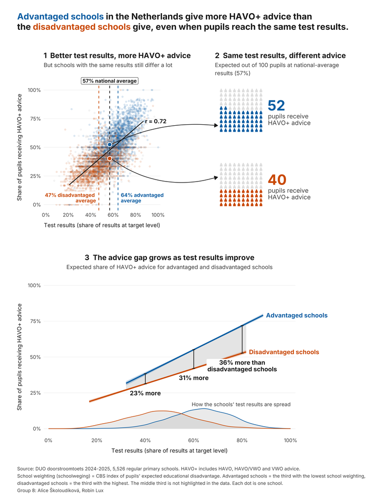

```r
## ---- Combine ---------------------------------------------------------------

headline <- paste0(
  "<span style='color:", blue, "'>Advantaged schools</span> in the ",
  "Netherlands give more HAVO+ advice than<br>the <span style='color:",
  orange, "'>disadvantaged schools</span> give, even when pupils reach the ",
  "same test results."
)
caption <- paste0(
  "Source: DUO doorstroomtoets 2024-2025, ",
  format(nrow(schools), big.mark = ","), " regular primary schools. ",
  "HAVO+ includes HAVO, HAVO/VWO and VWO advice.\n",
  "School weighting (schoolweging) = CBS index of pupils' expected ",
  "educational disadvantage. Advantaged schools = the third with the lowest ",
  "school weighting,\ndisadvantaged schools = the third with the highest. ",
  "The middle third is not highlighted in the data. Each dot is one school.\n",
  "Group 8: Alice Školoudíková, Robin Lux"
)

## Panels 1 and 2 next to each other, panel 3 under them at full width
top_row <- (p1 | p2) + plot_layout(widths = c(1.45, 1))
(top_row / p3) +
  plot_layout(heights = c(1, 1.25)) +
  plot_annotation(
    title = headline,
    caption = caption,
    theme = theme(
      plot.title = ggtext::element_markdown(
        family = "inter", face = "bold", size = 26, colour = ink,
        margin = margin(b = 44), lineheight = 1.2
      ),
      plot.caption = element_text(
        family = "inter", size = 14, colour = muted, hjust = 0,
        lineheight = 1.3, margin = margin(t = 30)
      ),
      plot.margin = margin(40, 32, 24, 32)
    )
  )
```

The headline states the conclusion; its coloured group names are the legend.

1. Better test results are related to more HAVO+ advice (r = 0.72), but the groups start from different points. 64% of results reach the target level at advantaged schools, 47% at disadvantaged ones.
2. At the national average (57%), the lines predict 52 out of 100 pupils with HAVO+ advice at an advantaged school and 40 at a disadvantaged one.
3. As the gap increases, advantaged schools give 23% more HAVO+ advice at 40% of results at target level and 36% more at 80%. The curves at the bottom show the differences between the groups, because disadvantaged schools with very high results are rare.

Everything except the main message is grey. Blue and orange are colourblind-friendly and is used for the groups in every graph. The national average is the only reference point, and confidence bands show uncertainty.

**Statistical test.** A linear regression of the HAVO+ share on test results, group and their interaction, weighted by groep 8 pupils, shows a 12.2 % gap at the national average (95% CI [11.3, 13.0], *p* < .001), growing 3.0 % per 10 points (95% CI [2.5, 3.6], *p* < .001).

### Robustness

```r
## Fit the interaction model on the least and the most disadvantaged third
robust_fit <- function(data, check, x_col = "pct_target", weighted = TRUE) {
  outer <- droplevels(data[data$disadvantage != "Middle", ])
  pupil_weights <- if (weighted) outer$n_groep8 else rep(1, nrow(outer))
  fit <- lm(
    reformulate(paste(x_col, "* disadvantage"), response = "pct_havo_plus"),
    data = outer, weights = pupil_weights
  )
  coefs <- summary(fit)$coefficients[
    paste0(x_col, ":disadvantageMost disadvantaged"),
  ]
  at_avg <- data.frame(
    disadvantage = c("Least disadvantaged", "Most disadvantaged")
  )
  at_avg[[x_col]] <- national_target
  pred <- unname(round(100 * predict(fit, at_avg)))
  data.frame(
    check = check,
    gap_growth = -10 * coefs[["Estimate"]],
    p = coefs[["Pr(>|t|)"]],
    advantaged = pred[1],
    disadvantaged = pred[2]
  )
}

## Rerun the data-prep chunk above with another value for "<5"
schools_with <- function(value) {
  old <- options(hidden_value = value)
  on.exit(options(old))
  prep_env <- new.env()
  eval(parse(text = knitr::knit_code$get("data-prep")), envir = prep_env)
  prep_env$schools
}

## HAVO+ share with VMBO-GT/HAVO counted as HAVO+
schools_gt <- schools |>
  mutate(pct_havo_plus = (VMBO_GT_HAVO + HAVO + HAVO_VWO + VWO) / n_groep8)

robustness <- bind_rows(
  robust_fit(schools, "Main analysis (\"<5\" = 2.5)"),
  robust_fit(schools_with(1), "\"<5\" = 1"),
  robust_fit(schools_with(4), "\"<5\" = 4"),
  robust_fit(schools, "Unweighted", weighted = FALSE),
  robust_fit(filter(schools, n_groep8 >= 20), "Only schools with 20+ pupils"),
  robust_fit(schools_gt, "VMBO-GT/HAVO counted as HAVO+")
)

## Show the checks as a table
robustness |>
  transmute(
    Check = check,
    `Extra gap per 10 points` = paste(round(gap_growth, 1), "pp"),
    `*p*` = apa_p(p),
    `HAVO+ out of 100 at national average` = paste(
      advantaged, "vs.", disadvantaged
    )
  ) |>
  knitr::kable(align = "lccc")
```

| Check | Extra gap per 10 points | *p* | HAVO+ out of 100 at national average |
| --- | --- | --- | --- |
| Main analysis (“<5” = 2.5) | 3 pp | < .001 | 52 vs. 40 |
| “<5” = 1 | 2.2 pp | < .001 | 57 vs. 41 |
| “<5” = 4 | 3.2 pp | < .001 | 50 vs. 40 |
| Unweighted | 2.5 pp | < .001 | 52 vs. 40 |
| Only schools with 20+ pupils | 3.3 pp | < .001 | 53 vs. 40 |
| VMBO-GT/HAVO counted as HAVO+ | 1.4 pp | < .001 | 67 vs. 55 |

```r
## Same model for each subject separately
subject_check <- bind_rows(
  robust_fit(schools, "Maths", x_col = "pct_maths_1s"),
  robust_fit(schools, "Reading", x_col = "pct_reading_2f"),
  robust_fit(schools, "Writing", x_col = "pct_writing_2f")
)
```

Based on the results, direction and significance never change, only size. With “<5” = 1 the gap at the national average is 16 pupils out of 100, with “<5” = 4 it is 10. Counting VMBO-GT/HAVO as HAVO+ slows the growth but the gap remains the same. The gap also grows for each subject separately (maths 1.9, reading 4.6, writing 1.4 points per 10 points).

## Conclusion

At the national average, 12 fewer pupils out of 100 get HAVO+ advice at a disadvantaged school, and the gap is largest when the pupils do well. For teachers at secondary schools: pupils from disadvantaged primary schools may start below the track their test results suggest, so watch for those who could move up.

We compare schools, not pupils, so we cannot say which advice a particular child got. The figure shows a difference, but not the cause so if teachers use more than the test, and we cannot see that. We have one school year and left out 367 schools with several locations, so the pattern may differ for them. Within our data, the results did not depend on the choice we tested.

## AI use

We used Claude Code (Claude Opus) for writing the R code for the data preparation and improving the figures (styling, annotations, layout). Also to quickly rendered alternative versions of the figures so we could choose the best one, and helped with drafting parts of this report, which we rewrote and checked against our analysis.

We did not use it to interpret the data or to give conclusions. Also we wrote the message and the headline ourselves to make it understandable for our audience. We gave it our research question, the assignment and our rules.

We checked its work regularly and recomputed numbers in R. It did make many mistakes, including building a page we had not asked for, making the figures very messy, using small fonts and using labels that were hard to understand. We rejected most of the drafts and manually adjusted the code it produced.